# AT4

Rajkomal Kaur

2025-09-23

# Part 1: Importing files, data wrangling, mathematical operations, plots and saving code on GitHub

# Downloading Data

To download the file with R, the URL obtained after clicking “view raw” is used as the following command suggests. First, the file named “gene_expression.tsv” was downloaded. Similarly, the other file containing growth data was downloaded. The commands used to perform these operations are given below.

```r
library("R.utils")
URL="https://raw.githubusercontent.com/ghazkha/Assessment4/refs/heads/main/gene_expression.tsv"
download.file(URL,destfile="gene_expression.tsv")
list.files()
```

```
##  [1] "acetobacter_cds.fa"    "acetobacter_cds.fa.gz" "at4.html"
##  [4] "at4.Rmd"               "AT4.Rproj"             "ecoli_cds.fa"
##  [7] "ecoli_cds.fa.gz"       "gene_expression.tsv"   "growth_data.csv"
## [10] "LICENSE"               "README.md"
```

```r
library("R.utils")

URL="https://raw.githubusercontent.com/ghazkha/Assessment4/refs/heads/main/growth_data.csv"
download.file(URL,destfile="growth_data.csv")
list.files()
```

```
##  [1] "acetobacter_cds.fa"    "acetobacter_cds.fa.gz" "at4.html"
##  [4] "at4.Rmd"               "AT4.Rproj"             "ecoli_cds.fa"
##  [7] "ecoli_cds.fa.gz"       "gene_expression.tsv"   "growth_data.csv"
## [10] "LICENSE"               "README.md"
```

#Reading the file The code below reads the uncompressed tsv file into R using the read.delim function. The (head(geneExpression)) function then provides a table of values for the first six genes.

```r
geneExpression <- read.delim("gene_expression.tsv")
head(geneExpression)
```

```
##                Name_Description GTEX.1117F.0226.SM.5GZZ7
## 1     ENSG00000223972.5_DDX11L1                        0
## 2      ENSG00000227232.5_WASH7P                      187
## 3   ENSG00000278267.1_MIR6859-1                        0
## 4 ENSG00000243485.5_MIR1302-2HG                        1
## 5     ENSG00000237613.2_FAM138A                        0
## 6      ENSG00000268020.3_OR4G4P                        0
##   GTEX.1117F.0426.SM.5EGHI GTEX.1117F.0526.SM.5EGHJ
## 1                        0                        0
## 2                      109                      143
## 3                        0                        1
## 4                        0                        0
## 5                        0                        0
## 6                        1                        0
```

# Gene identifiers as row names

In the previous table, the gene identifiers are a separate column and not the row names. the commands given below makes the gene identifiers as row names. The (head(geneExpression)) function then provides a table of values for the first six genes.

```r
rownames(geneExpression) <- geneExpression[,1]
geneExpression <- geneExpression[,-1]
head(geneExpression)
```

```
##                               GTEX.1117F.0226.SM.5GZZ7 GTEX.1117F.0426.SM.5EGHI
## ENSG00000223972.5_DDX11L1                            0                        0
## ENSG00000227232.5_WASH7P                           187                      109
## ENSG00000278267.1_MIR6859-1                          0                        0
## ENSG00000243485.5_MIR1302-2HG                        1                        0
## ENSG00000237613.2_FAM138A                            0                        0
## ENSG00000268020.3_OR4G4P                             0                        1
##                               GTEX.1117F.0526.SM.5EGHJ
## ENSG00000223972.5_DDX11L1                            0
## ENSG00000227232.5_WASH7P                           143
## ENSG00000278267.1_MIR6859-1                          1
## ENSG00000243485.5_MIR1302-2HG                        0
## ENSG00000237613.2_FAM138A                            0
## ENSG00000268020.3_OR4G4P                             0
```

# Mean Column

Another column was created using the following code. The newly created column consisted of the mean of the other columns. Again, the (head(geneExpression)) function was used to view values for the first six genes.

```r
geneExpression$Mean <- rowMeans(geneExpression)
head(geneExpression)
```

```
##                               GTEX.1117F.0226.SM.5GZZ7 GTEX.1117F.0426.SM.5EGHI
## ENSG00000223972.5_DDX11L1                            0                        0
## ENSG00000227232.5_WASH7P                           187                      109
## ENSG00000278267.1_MIR6859-1                          0                        0
## ENSG00000243485.5_MIR1302-2HG                        1                        0
## ENSG00000237613.2_FAM138A                            0                        0
## ENSG00000268020.3_OR4G4P                             0                        1
##                               GTEX.1117F.0526.SM.5EGHJ        Mean
## ENSG00000223972.5_DDX11L1                            0   0.0000000
## ENSG00000227232.5_WASH7P                           143 146.3333333
## ENSG00000278267.1_MIR6859-1                          1   0.3333333
## ENSG00000243485.5_MIR1302-2HG                        0   0.3333333
## ENSG00000237613.2_FAM138A                            0   0.0000000
## ENSG00000268020.3_OR4G4P                             0   0.3333333
```

#Highest Mean expression The column created in last step was sorted using the following command “highest_mean <- geneExpression[order (geneExpression$Mean, decreasing=TRUE), ]”. This command sorted the mean in descending order and head command was used to view first 10 genes with highest mean expression.

```r
highest_mean <- geneExpression[order (geneExpression$Mean, decreasing=TRUE), ]
head (highest_mean,10)
```

```
##                           GTEX.1117F.0226.SM.5GZZ7 GTEX.1117F.0426.SM.5EGHI
## ENSG00000198804.2_MT-CO1                    267250                  1101779
## ENSG00000198886.2_MT-ND4                    273188                   991891
## ENSG00000198938.2_MT-CO3                    250277                  1041376
## ENSG00000198888.2_MT-ND1                    243853                   772966
## ENSG00000198899.2_MT-ATP6                   141374                   696715
## ENSG00000198727.2_MT-CYB                    127194                   638209
## ENSG00000198763.3_MT-ND2                    159303                   543786
## ENSG00000211445.11_GPX3                     464959                    39396
## ENSG00000198712.1_MT-CO2                    128858                   545360
## ENSG00000156508.17_EEF1A1                   317642                    39573
##                           GTEX.1117F.0526.SM.5EGHJ     Mean
## ENSG00000198804.2_MT-CO1                    218923 529317.3
## ENSG00000198886.2_MT-ND4                    277628 514235.7
## ENSG00000198938.2_MT-CO3                    223178 504943.7
## ENSG00000198888.2_MT-ND1                    194032 403617.0
## ENSG00000198899.2_MT-ATP6                   151166 329751.7
## ENSG00000198727.2_MT-CYB                    141359 302254.0
## ENSG00000198763.3_MT-ND2                    149564 284217.7
## ENSG00000211445.11_GPX3                     306070 270141.7
## ENSG00000198712.1_MT-CO2                    122816 265678.0
## ENSG00000156508.17_EEF1A1                   339347 232187.3
```

# Number of genes with mean<10

To calculate the number of genes with the mean less than 10, the following commands were used. The logical condition (geneExpression$Mean < 10), returns TRUE for genes below 10.The sum() function counts the number of TRUE values, giving the total number of genes with mean expression less than 10.The number of genes with mean less than 10 were counted to be 35988.

```r
sum(geneExpression$Mean < 10)
```

```
## [1] 35988
```

# Histogram of Mean Values

The histogram was created using a log10 transformation of mean expression values (with +1 offset to handle zeros) to effectively visualize the highly skewed distribution typical of RNA-seq data. The hist() was used to create the histogram. Elements like xlab, ylab, color and border were used to enhance visualisation and breaks decided the number of bins. The plot reveals that the most genes show low expression levels (left peak) while fewer genes exhibit high expression (right tail).

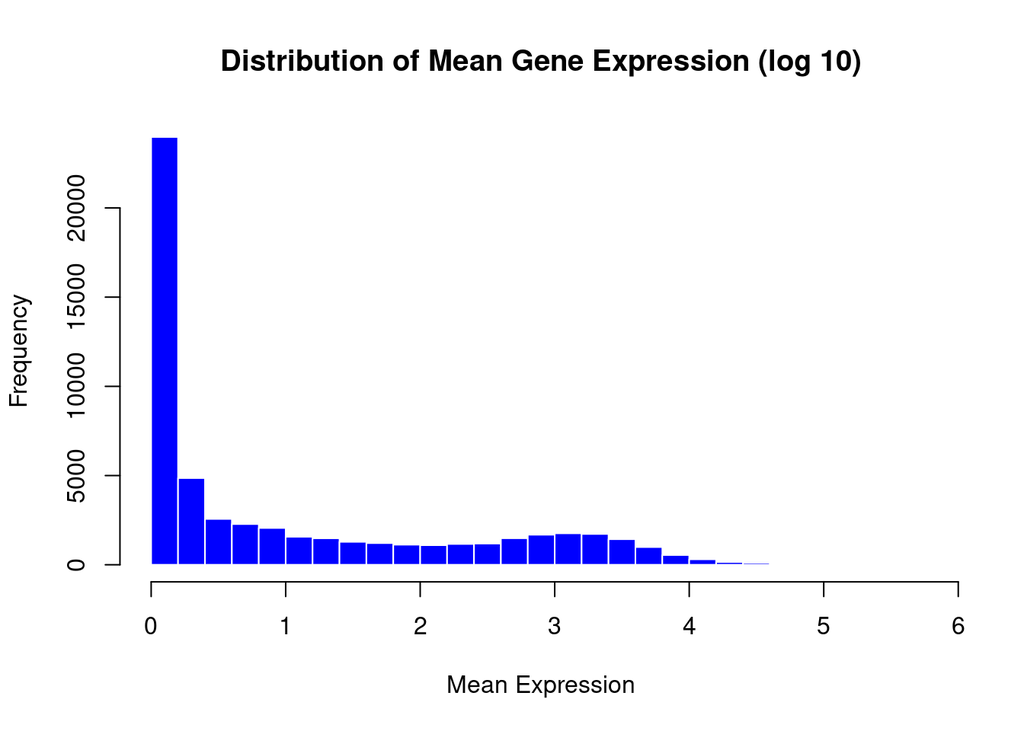

```r
hist(log10(geneExpression$Mean + 1), main = "Distribution of Mean Gene Expression (log 10)", xlab = "Mean Expression", ylab = "Frequency", col = "blue", border = "white", breaks = 25)
```

# Growth data: Column names The code below reads the csv file into R using the read.csv function. The colnames(growthData) fuction lists the column names.The column names are “Site”,“TreeID”,“Circumf_2005_cm”,“Circumf_2010_cm”,“Circumf_2015_cm”, and “Circumf_2020_cm”.

```r
growthData <- read.csv("growth_data.csv")
colnames(growthData)
```

```
## [1] "Site"            "TreeID"          "Circumf_2005_cm" "Circumf_2010_cm"
## [5] "Circumf_2015_cm" "Circumf_2020_cm"
```

# Mean and Standard Deviation (tree circumference)

The tapply() function splits the data by site and applies the statistical functions to each group.The “na.rm = TRUE” function excludes missing values from calculation. The results are combined into a clean dataframe (summary_stats) showing growth patterns for each site.The row.names = NULL ensured clean output without duplicate identifiers. THe head (summary_stats) function was ussed to visualise results.

```r
mean_start <- tapply(growthData$Circumf_2005_cm, growthData$Site, mean, na.rm = TRUE)
sd_start <- tapply(growthData$Circumf_2005_cm, growthData$Site, sd, na.rm = TRUE)
mean_end <- tapply(growthData$Circumf_2020_cm, growthData$Site, mean, na.rm = TRUE)
sd_end <- tapply(growthData$Circumf_2020_cm, growthData$Site, sd, na.rm = TRUE)
summary_stats <- data.frame( Site = names(mean_start), Mean_start = mean_start,  SD_start = sd_start, Mean_end = mean_end, SD_end = sd_end, row.names = NULL )
head (summary_stats)
```

```
##        Site Mean_start  SD_start Mean_end   SD_end
## 1 northeast      5.292 0.9140267   54.228 25.22795
## 2 southwest      4.862 1.1474710   45.596 17.87345
```

# Box plot of tree circumference

A combined dataframe (plot_data) was created and all circumference values were combimed as well. ‘rep’ function was used to create vectors by repeating values. The ‘each = nrow(growth_data)’ means to repeat each element this many times before moving to the next element. The boxplot was created using boxplot() code.The code generated a box plot comparing tree circumference distributions between northeast (blue) and southwest (red) sites in 2005(start) and 2020(end). It shows four boxes representing each site-time combination, allowing visualization of growth patterns and variability.

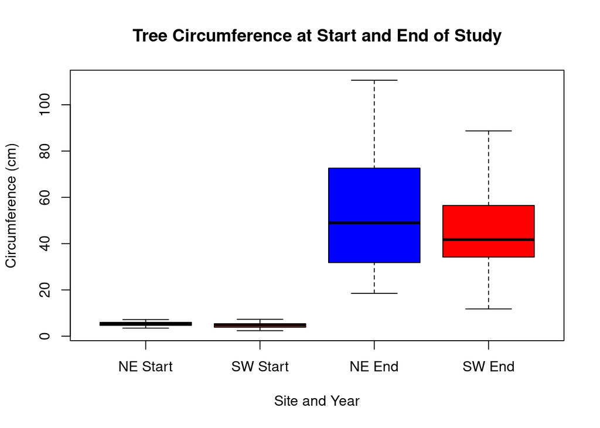

```r
plot_data <- data.frame( Circumference = c(growthData$Circumf_2005_cm, growthData$Circumf_2020_cm), Site = rep(growthData$Site, 2), Time = rep(c("2005", "2020"), each = nrow(growthData)))
boxplot(Circumference ~ Site + Time, data = plot_data, xlab = "Site and Year",  ylab = "Circumference (cm)", main = "Tree Circumference at Start and End of Study", col = c("blue", "red"), names = c("NE Start", "SW Start", "NE End", "SW End"))
```

# Mean growth over last 10 years The growth over the last 10 years can be calculated as the difference between 2020 and 2010, then the mean per site can be computed. The datframe (growth_10yr) was created and it consisted of mean difference values. Then, tapply() was used to calculate the mean growth for each site (Northeast vs Southwest). Finally, it was visualised and the Mean growth was 42.94 and 35.49 for northeast and southwest sites, respectively.

```r
growth_10yr <- growthData$Circumf_2020_cm - growthData$Circumf_2010_cm
mean_growth <- tapply(growth_10yr, growthData$Site, mean, na.rm = TRUE)
mean_growth
```

```
## northeast southwest
##     42.94     35.49
```

# t.test

The code “t.test(growth_10yr ~ Site, data = growth_data)” was used to perform an independent two-sample t-test to determine if there is a statistically significant difference in the mean 10-year growth between the northeast and southwest sites. The p value was recorded to be 0.06229.

```r
t.test(growth_10yr ~ Site, data = growthData)
```

```
##
##  Welch Two Sample t-test
##
## data:  growth_10yr by Site
## t = 1.8882, df = 87.978, p-value = 0.06229
## alternative hypothesis: true difference in means between group northeast and group southwest is not equal to 0
## 95 percent confidence interval:
##  -0.3909251 15.2909251
## sample estimates:
## mean in group northeast mean in group southwest
##                   42.94                   35.49
```

# Part 2: Examining biological sequence diversity

#Question 1 # Downloading the data The commands used to download the files are given below. The URL for particular files were obtained from ensemble. download.file() command was used to download the files and gunzip() command unzipped the files. list.files() was used to check if the files were downloaded.

```r
library("R.utils")

URL="https://ftp.ensemblgenomes.ebi.ac.uk/pub/bacteria/release-62/fasta/bacteria_80_collection/acetobacter_aceti_gca_002005445/cds/Acetobacter_aceti_gca_002005445.ASM200544v1.cds.all.fa.gz"
download.file(URL,destfile="acetobacter_cds.fa.gz")
#gunzip("acetobacter_cds.fa.gz")
URL="http://ftp.ensemblgenomes.org/pub/bacteria/release-53/fasta/bacteria_0_collection/escherichia_coli_str_k_12_substr_mg1655_gca_000005845/cds/Escherichia_coli_str_k_12_substr_mg1655_gca_000005845.ASM584v2.cds.all.fa.gz"
download.file(URL,destfile="ecoli_cds.fa.gz")
#gunzip("ecoli_cds.fa.gz")
list.files()
```

```
##  [1] "acetobacter_cds.fa"    "acetobacter_cds.fa.gz" "at4_files"
##  [4] "at4.html"              "at4.Rmd"               "AT4.Rproj"
##  [7] "ecoli_cds.fa"          "ecoli_cds.fa.gz"       "gene_expression.tsv"
## [10] "growth_data.csv"       "LICENSE"               "README.md"
```

# Number of coding sequences

The seqinr library was loaded: This library provides tools for biological sequence retrieval and analysis.The code below reads the uncompressed FASTA files containing coding sequences into R using the read.fasta function from the seqinr package. Length() was used to count the coding sequences. cds_table was created.The total number of coding DNA sequences (CDS) identified in Escherichia coli K-12 was approximately 4,239, whereas Acetobacter aceti contained about 3,402 CDS.his suggests that E. coli has a slightly larger and more gene-rich genome compared to A. aceti. These differences likely reflect their ecological specialisations. E. coli is a facultative anaerobe inhabiting nutrient-rich environments, while A. aceti is an aerobic acetic acid bacterium that thrives in acidic conditions and may have streamlined its genome to support specific metabolic pathways related to ethanol oxidation and acetic acid production.

```r
library("seqinr")
cds_ecoli <- seqinr::read.fasta("ecoli_cds.fa")
cds_acetobacter <- seqinr::read.fasta("acetobacter_cds.fa")
ecoli_count <- length(cds_ecoli)
acetobacter_count <- length(cds_acetobacter)
cds_table <- data.frame(Organism = c("Escherichia coli", "Acetobacter aceti"), CDS_Count = c(ecoli_count, acetobacter_count))
print(cds_table)
```

```
##            Organism CDS_Count
## 1  Escherichia coli      4239
## 2 Acetobacter aceti      3402
```

# Question 2

# Coding DNA

To determine the total length of our sequence, the code below extracts the lengths of genes from the cds object by converting the first column of the summary to numeric values. It then calculates the total length of all genes by summing these values (using sum(), used while creating table). The table was created using the code below. The total coding DNA is 3978528 and 3236568 in E.coli and A.aceti, respectively.The larger coding capacity of E. coli reflects its broader metabolic versatility, whereas A. aceti has a smaller, more specialized genome adapted to its acetic acid-producing lifestyle.

```r
ecoli_len <- as.numeric(summary(cds_ecoli)[,1])
acetobacter_len <- as.numeric(summary(cds_acetobacter)[,1])
length_table <- data.frame(Organism = c("Escherichia coli", "Acetobacter aceti"), Total_coding_DNA = c(sum(ecoli_len), sum(acetobacter_len)))
print(length_table)
```

```
##            Organism Total_coding_DNA
## 1  Escherichia coli          3978528
## 2 Acetobacter aceti          3236568
```

# Question 3

# Mean and Median length of coding sequence length

Length of all coding sequences was calculated using sum(). The mean and median are described in the tanle below. mean() and median() functions were used. For E.coli, mean and median are 938.6 and 831, respectively. For Acetobacter aceti, mean and median length are 951.4 and 819, respectively.Acetobacter has slightly longer genes on average (+12.8 bp).E. coli has longer typical genes (median +12 bp). Acetobacter has more very long genes (higher mean but lower median).Overall, Both have similar gene lengths, but Acetobacter has more extreme long genes.

```r
sum(ecoli_len)
```

```
## [1] 3978528
```

```r
sum(acetobacter_len)
```

```
## [1] 3236568
```

```r
length_stats <- data.frame( Organism = c("Escherichia coli", "Acetobacter aceti"), Mean_Length = c(round(mean(ecoli_len), 1), round(mean(acetobacter_len), 1)), Median_Length = c(median(ecoli_len), median(acetobacter_len)))
print(length_stats)
```

```
##            Organism Mean_Length Median_Length
## 1  Escherichia coli       938.6           831
## 2 Acetobacter aceti       951.4           819
```

# Boxplot

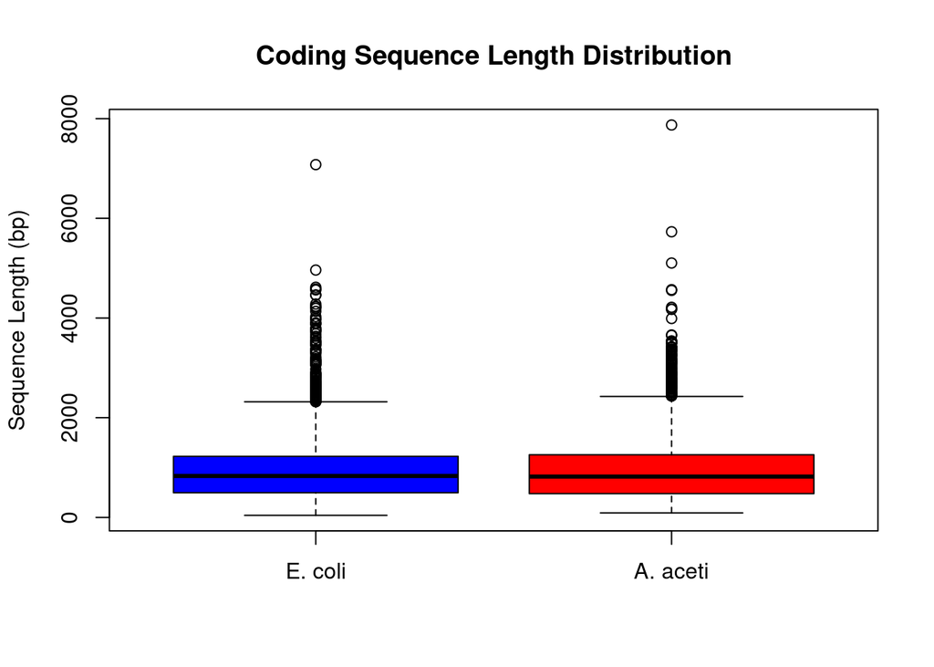

```r
boxplot(ecoli_len, acetobacter_len, names = c("E. coli", "A. aceti"), main = "Coding Sequence Length Distribution", ylab = "Sequence Length (bp)", col = c("blue", "red"))
```

# Question 4 # DNA base Frequency The commands begin by calculating the DNA base frequencies for both organisms. The count() function with argument 1 counts the occurrence of each individual nucleotide across all coding sequences, which are first combined into single strings using unlist(). These frequency counts are then organized into a comparative data frame that displays the four DNA bases alongside their respective counts in E. coli and Acetobacter. Finally, the print() function displays this table, revealing that both organisms exhibit GC-rich genomic compositions with guanine being the most prevalent base in each.Both organisms are GC-rich (G+C > A+T). E. coli has higher absolute counts (larger genome/sample).G is most common base in both organisms.Similar relative base preferences was observed despite different genome size,

```r
DNAfreq_ecoli <- count(unlist(cds_ecoli),1)
DNAfreq_acetobacter <- count(unlist(cds_acetobacter),1)
DNAfreq_table <- data.frame(Base = names(DNAfreq_ecoli),
  E_coli= DNAfreq_ecoli,
  A_aceti = DNAfreq_acetobacter)
print(DNAfreq_table)
```

```
##   Base E_coli.Var1 E_coli.Freq A_aceti.Var1 A_aceti.Freq
## 1    a           a      955768            a       655335
## 2    c           c      977594            c       917585
## 3    g           g     1088501            g       956936
## 4    t           t      956665            t       706712
```

# Barplot

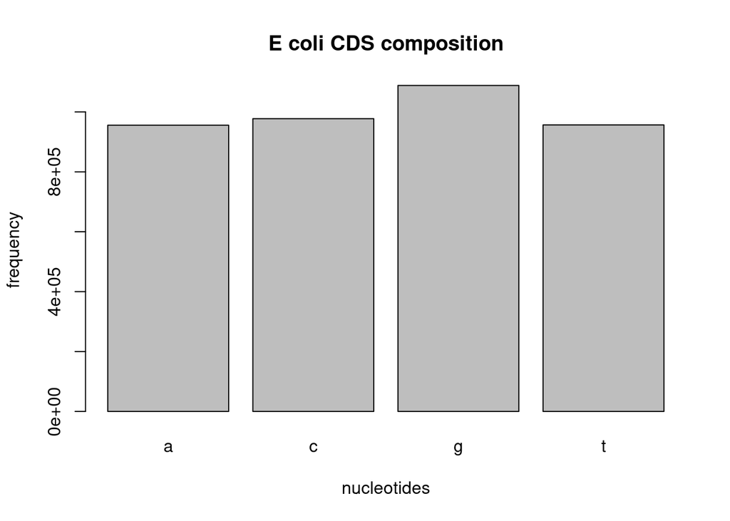

```r
barplot(DNAfreq_ecoli,xlab="nucleotides",ylab="frequency", main="E coli CDS composition")
```

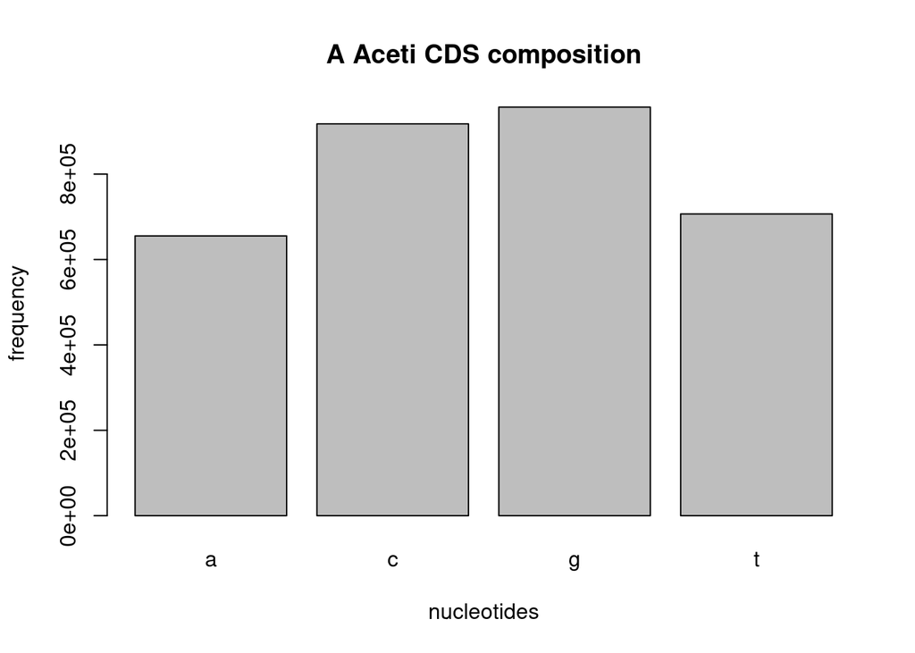

```r
barplot(DNAfreq_acetobacter,xlab="nucleotides",ylab="frequency", main="A Aceti CDS composition")
```

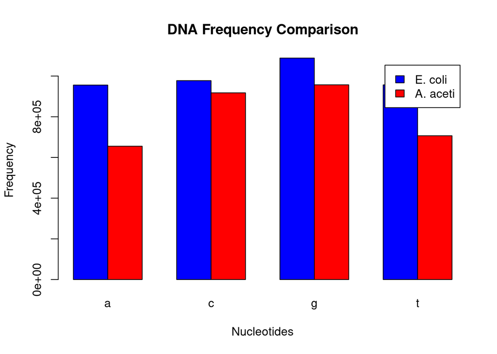

```r
barplot(rbind(DNAfreq_ecoli, DNAfreq_acetobacter), beside = TRUE, col = c("blue", "red"), main = "DNA Frequency Comparison", xlab = "Nucleotides", ylab = "Frequency", legend = c("E. coli", "A. aceti"))
```

# Amino acid frequency

```r
ecoli_prot <- lapply(cds_ecoli, translate)
ecoli_all_aa <- unlist(ecoli_prot)
ecoli_aa <- ecoli_all_aa[ecoli_all_aa != "*"]
ecoli_aa_freq <- count(ecoli_aa, wordsize = 1, alphabet = ecoli_aa)
print("E. coli Amino Acid Frequency:")
```

```
## [1] "E. coli Amino Acid Frequency:"
```

```r
print(ecoli_aa_freq)
```

```
##
##      A      C      D      E      F      G      H      I      K      L      M
## 126127  15376  67796  76338  51561  97246  29995  79511  58113 141731  37007
##      N      P      Q      R      S      T      V      W      Y
##  51503  58700  58799  73111  76412  71025  93989  20196  37401
```

```r
acetobacter_prot <- lapply(cds_acetobacter, translate)
acetobacter_all_aa <- unlist(acetobacter_prot)
acetobacter_aa <- acetobacter_all_aa[acetobacter_all_aa != "*"]
acetobacter_aa_freq <- count(acetobacter_aa, wordsize = 1, alphabet = acetobacter_aa)
print("Acetobacter aceti Amino Acid Frequency:")
```

```
## [1] "Acetobacter aceti Amino Acid Frequency:"
```

```r
print(acetobacter_aa_freq)
```

```
##
##      A      C      D      E      F      G      H      I      K      L      M
## 118064  11225  59197  58691  39736  89384  24858  56386  34912 108938  27132
##      N      P      Q      R      S      T      V      W      Y
##  30835  56500  35749  74377  69062  62625  78530  14942  24311
```

# Barplot

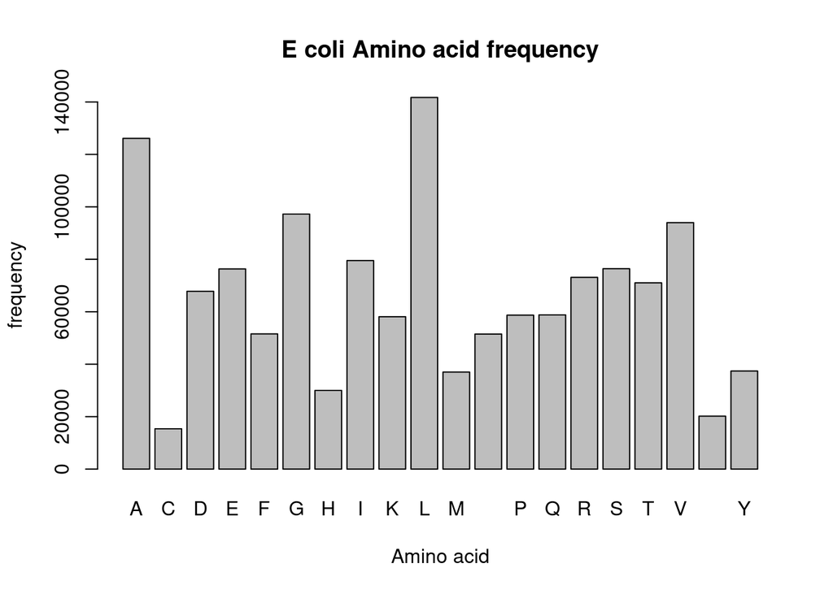

```r
barplot(ecoli_aa_freq ,xlab="Amino acid",ylab="frequency", main="E coli Amino acid frequency")
```

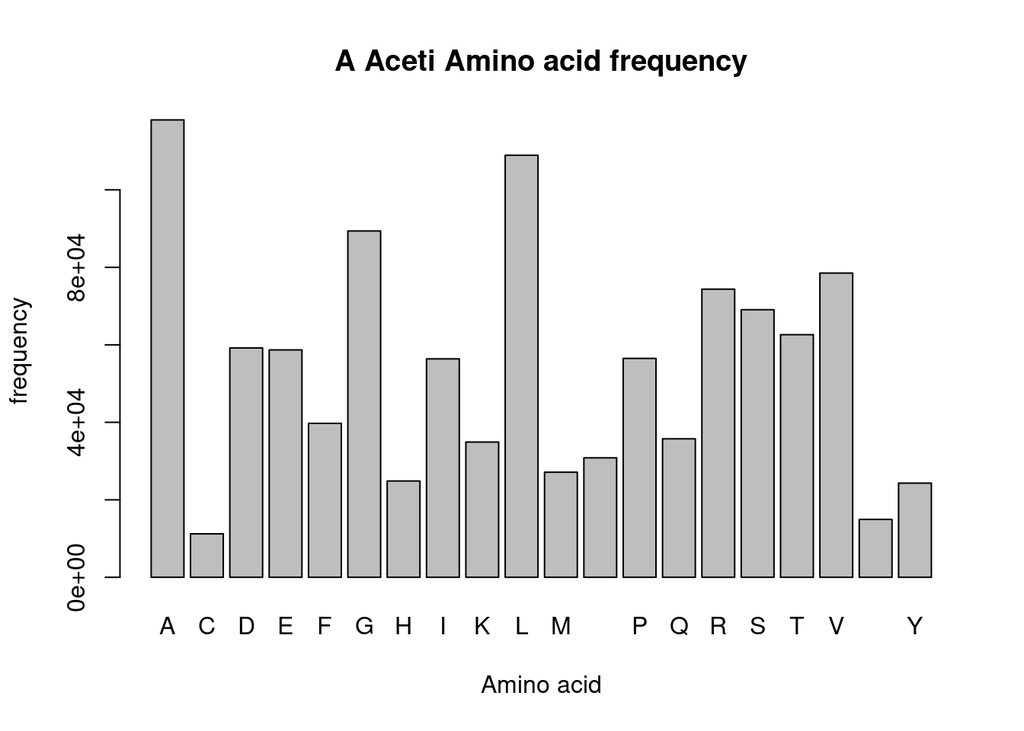

```r
barplot(acetobacter_aa_freq ,xlab="Amino acid",ylab="frequency", main="A Aceti Amino acid frequency")
```

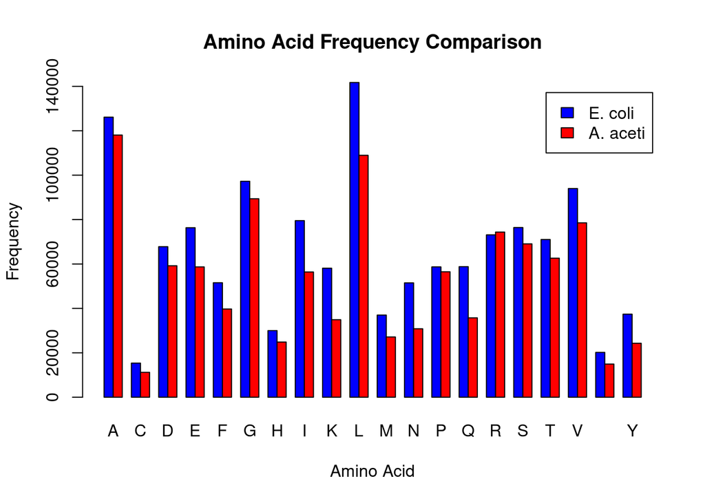

```r
barplot(rbind(ecoli_aa_freq, acetobacter_aa_freq), beside = TRUE, col = c("blue", "red"), main = "Amino Acid Frequency Comparison", xlab = "Amino Acid", ylab = "Frequency", legend = c("E. coli", "A. aceti"))
```

# Question 5 # Codon Usage The uco() function calculates Relative Synonymous Codon Usage (RSCU) values for all codons in both organisms.unlist() function converts a list into a single vector, RSCU measures codon preference by comparing observed frequency to expected equal usage among synonymous codons. The results are compiled into a comparative table showing codon, amino acid, RSCU scores, frequencies, and efficiencies for both species.The codon usage table reveals that both E. coli and Acetobacter exhibit similar codon preference patterns with certain synonymous codons being strongly favored over others for the same amino acid.

```r
ecoli_codon <- uco((unlist(cds_ecoli)), index = "rscu", as.data.frame = TRUE)
acetobacter_codon <- uco((unlist(cds_acetobacter)), index = "rscu", as.data.frame = TRUE)
codon_table <- data.frame( Codon = ecoli_codon$codon, Amino_Acid = ecoli_codon$AA, Ecoli_RSCU = ecoli_codon$RSCU, Aaceti_RSCU = acetobacter_codon$RSCU, ecoli_freq = ecoli_codon$freq, Aaceti_freq = acetobacter_codon$freq, ecoli_eff = ecoli_codon$eff, Aaceti_eff = acetobacter_codon$eff)
print(codon_table)
```

```
##    Codon Amino_Acid Ecoli_RSCU Aaceti_RSCU   ecoli_freq  Aaceti_freq ecoli_eff
## 1    aaa        Lys  1.5346652   0.9176787 0.0336244963 0.0148481354     44592
## 2    aac        Asn  1.1049453   1.0496514 0.0214556741 0.0150001483     28454
## 3    aag        Lys  0.4653348   1.0823213 0.0101954793 0.0175120683     13521
## 4    aat        Asn  0.8950547   0.9503486 0.0173800461 0.0135810525     23049
## 5    aca        Thr  0.5133967   0.8608703 0.0068738991 0.0124928628      9116
## 6    acc        Thr  1.7536924   1.3249661 0.0234802922 0.0192277746     31139
## 7    acg        Thr  1.0746075   1.3938842 0.0143879847 0.0202279081     19081
## 8    act        Thr  0.6583034   0.4202794 0.0088140639 0.0060990531     11689
## 9    aga        Arg  0.2111584   0.3828603 0.0019401648 0.0043991042      2573
## 10   agc        Ser  1.6718055   1.2262894 0.0160544302 0.0130833031     21291
## 11   agg        Arg  0.1165351   0.4010917 0.0010707478 0.0046085854      1420
## 12   agt        Ser  0.9019787   0.6227448 0.0086617463 0.0066440748     11487
## 13   ata        Ile  0.2069902   0.2330366 0.0041367058 0.0040598560      5486
## 14   atc        Ile  1.2648816   1.8158231 0.0252786960 0.0316344350     33524
```

[output cut: 115 more lines]

#Codon usage bias The code below calculates codon usage bias by computing the standard deviation of RSCU values for both organisms. sd () means standard deviation. For E. coli, the bias value is 0.555, while for A. aceti it is 0.529. These results indicate that both species exhibit moderate codon usage bias, with E. coli showing slightly stronger preferential use of specific synonymous codons. The small difference suggests similar evolutionary constraints on translational efficiency, though E. coli may have more optimized codon preferences for its cellular environment

```r
ecoli_bias <- sd(ecoli_codon$RSCU, na.rm = TRUE)
acetobacter_bias <- sd(acetobacter_codon$RSCU, na.rm = TRUE)
print("Codon usage bias for E. coli:")
```

```
## [1] "Codon usage bias for E. coli:"
```

```r
print(ecoli_bias)
```

```
## [1] 0.5549891
```

```r
print("Codon usage bias for A. aceti:")
```

```
## [1] "Codon usage bias for A. aceti:"
```

```r
print(acetobacter_bias)
```

```
## [1] 0.528663
```